# BS2280 – Econometrics I

# Homework 11: Multi-collinearity - Solution

## Question 1

What is multi-collinearity and how does its presence affect your regression results?

Multi-collinearity arises when a correlation exists between variables that move together, but that correlation is not perfect. There are two main problems:

1. Ceteris paribus will not hold anymore, making our marginal effect interpretations misleading.
2. The estimators have a larger variance, making precise estimation difficult. A larger variance means a low $t$ statistic and therefore statistically insignificant coefficients.

## Question 2

Work experience is generally found to be an important determinant of earnings. If a direct measure is lacking in a data set, it is standard practice to use potential work experience, $PWE$, defined by

$$\begin{equation*}
PWE = AGE – S – 5
\end{equation*}$$

as a proxy. This is the maximum number of years since the completion of full-time education, assuming that an individual enters first grade at the age of six. We first regress $EARNINGS$ on $S$ and $PWE$, and then fit the regression a second time adding $AGE$ as well. Comment on the regression results.

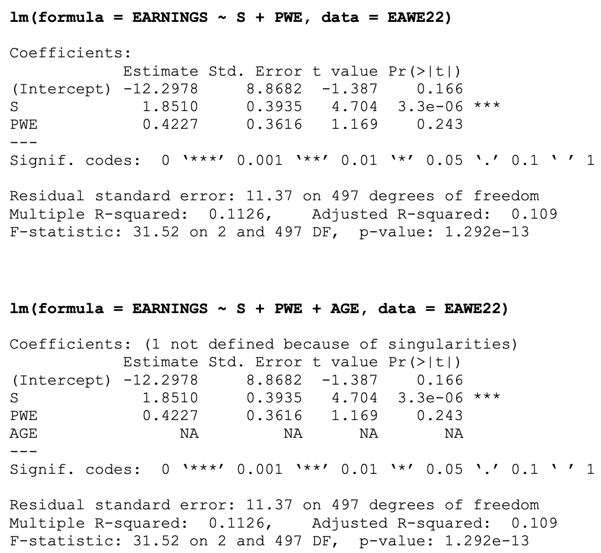

## Question 3

We regress $S$ on $SM$, $SF$, $ASVABAR$ (arithmetic reasoning), $ASVABWK$ (word knowledge), and $ASVABPC$ (paragraph comprehension) , the three components of the $ASVABC$ composite score. Compare the coefficients and their standard errors with those of $ASVABC$ in a regression of $S$ on $SM$, $SF$, and $ASVABC$. Making also reference to the correlation table, is multi-collinearity present?

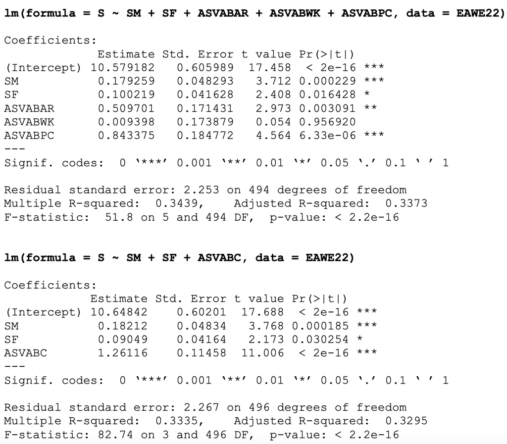

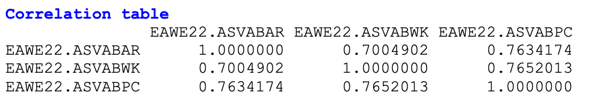

According to the correlation table, ASVABPC and ASVABWK have the highest correlation coefficient, which is 0.765.

ASVABAR and ASVABPC also have highly correlation and the correlation coefficient is 0.763.

As expected, the standard errors are greater than that for $ASVABC$ in previous regressions, indicating that multi-collinearity is present.